# Data analysis pilot study: test framing and bioinspired items

## 4.7 test for measurment invariance

*to check if items betweens different framing conditions were answered in a similar fashion (related to differential item functioning)*

## 4.8 ant colony algorithm

- Ant Colony / Genetic Algorithm
- if necessary add to CFAs regularized SEM (regSEM)

# 5 Compute mean scores

```r
dat$mean_Bioinspiration <- rowMeans(x = dat[,str_subset(colnames(dat), pattern = "^Bioinspiration")])
dat$mean_Bioinspiration_PN <- rowMeans(x = dat[,str_subset(colnames(dat), pattern = "^Bioinspiration-PN")])
dat$mean_Bioinspiration_IPI <- rowMeans(x = dat[,str_subset(colnames(dat), pattern = "^Bioinspiration-IPI")])
dat$mean_Bioinspiration_VRtN <- rowMeans(x = dat[,str_subset(colnames(dat), pattern = "^Bioinspiration-VRtN")])

dat$mean_Ecological <- rowMeans(x = dat[,str_subset(colnames(dat), pattern = "^EcologicalDimension")])
```

manifest correlations:

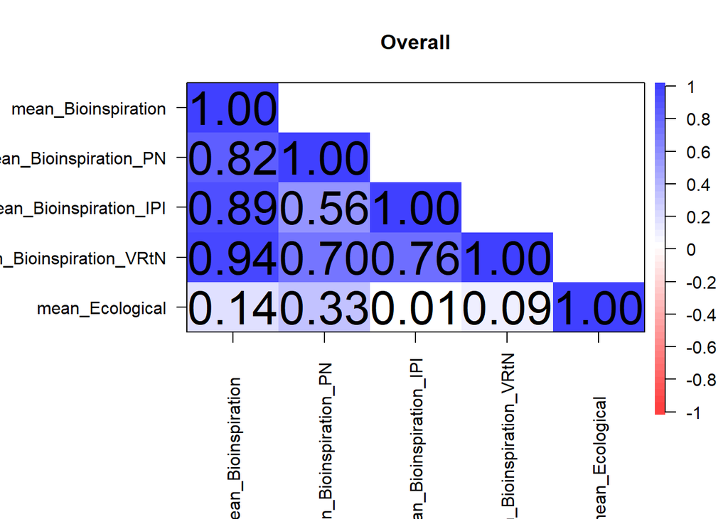

```r
psych::cor.plot(r = cor(dat[, str_detect(string = colnames(dat),
                                                   pattern = "^mean_")]
                        , use = "pairwise.complete.obs"),
                upper = FALSE, xlas = 2, main = "Overall")
```

# 6 Test Hypotheses

## 6.1 Descriptive

```r
# Summaries of participant-level scores by framing condition
eco_summary <- data_summary(dat, "mean_Ecological", "framingCondition")
bio_summary <- data_summary(dat, "mean_Bioinspiration", "framingCondition")

# View results
print(eco_summary)
```

```
  framingCondition mean_Ecological         se
1      bioinspired        4.848485 0.07519984
2          neutral        5.464467 0.06789697
3      sustainable        5.869347 0.06002766
```

```r
print(bio_summary)
```

```
  framingCondition mean_Bioinspiration         se
1      bioinspired            3.922865 0.03627758
2          neutral            3.476234 0.05016594
3      sustainable            3.172225 0.05824618
```

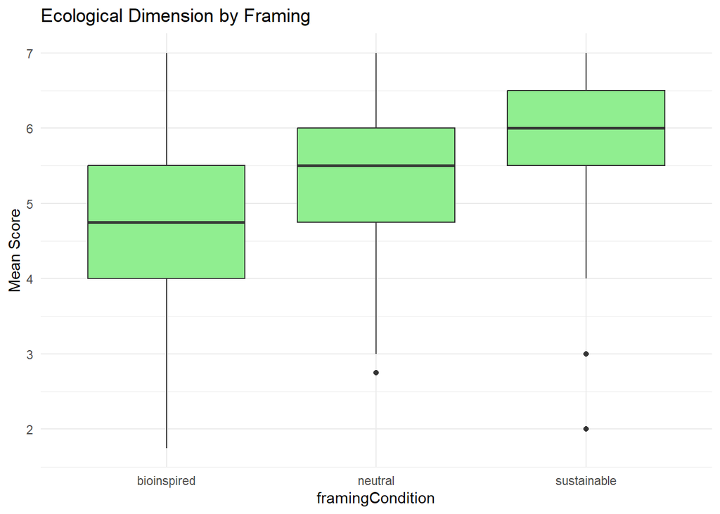

```r
# Plots the mean scores on the Bioinspiration & Ecological Dimension by Framing Condition
ggplot(dat, aes(x = framingCondition, y = mean_Ecological)) +
  geom_boxplot(fill = "lightgreen") +
  labs(title = "Ecological Dimension by Framing", y = "Mean Score") +
  theme_minimal()
```

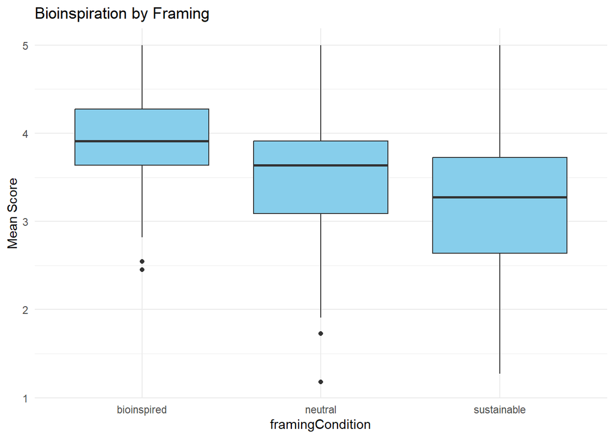

```r
ggplot(dat, aes(x = framingCondition, y = mean_Bioinspiration)) +
  geom_boxplot(fill = "skyblue") +
  labs(title = "Bioinspiration by Framing", y = "Mean Score") +
  theme_minimal()
```

## 6.2 ANOVAs

!!! to discuss

```r
tmp_removeIDs <- names(table(dat$PROLIFIC_PID))[table(dat$PROLIFIC_PID) >= 2]

dim(dat)
```

```
[1] 594  51
```

```r
dat <- dat[!dat$PROLIFIC_PID %in% tmp_removeIDs,]
dim(dat)
```

```
[1] 582  51
```

ANOVAs + post hoc tests:

```r
# --- ANOVA for Bioinspiration ---
aov_bio <- aov_ez(
  id = "PROLIFIC_PID",  # replace with your participant ID column name
  dv = "mean_Bioinspiration",
  data = dat,
  between = "framingCondition"
)
print(aov_bio)
```

```
Anova Table (Type 3 tests)

Response: mean_Bioinspiration
            Effect     df  MSE         F  ges p.value
1 framingCondition 2, 579 0.48 55.67 *** .161   <.001
---
Signif. codes:  0 '***' 0.001 '**' 0.01 '*' 0.05 '+' 0.1 ' ' 1
```

```r
# Post hoc (Tukey) for Bioinspiration
em_bio <- emmeans(aov_bio, "framingCondition")
bio_posthoc <- pairs(em_bio, adjust = "tukey")
print(bio_posthoc)
```

```
 contrast                  estimate     SE  df t.ratio p.value
 bioinspired - neutral        0.439 0.0704 579   6.234  <.0001
 bioinspired - sustainable    0.735 0.0701 579  10.495  <.0001
 neutral - sustainable        0.296 0.0700 579   4.234  0.0001

P value adjustment: tukey method for comparing a family of 3 estimates
```

```r
# --- ANOVA for Ecological Dimension ---
aov_eco <- aov_ez(
  id = "PROLIFIC_PID",  # replace with your participant ID column name
  dv = "mean_Ecological",
  data = dat,
  between = "framingCondition"
)
print(aov_eco)
```

```
Anova Table (Type 3 tests)

Response: mean_Ecological
            Effect     df  MSE         F  ges p.value
1 framingCondition 2, 579 0.91 59.06 *** .169   <.001
---
Signif. codes:  0 '***' 0.001 '**' 0.01 '*' 0.05 '+' 0.1 ' ' 1
```

```r
# Post hoc (Tukey) for Ecological
em_eco <- emmeans(aov_eco, "framingCondition")
eco_posthoc <- pairs(em_eco, adjust = "tukey")
print(eco_posthoc)
```

```
 contrast                  estimate     SE  df t.ratio p.value
 bioinspired - neutral       -0.633 0.0975 579  -6.494  <.0001
 bioinspired - sustainable   -1.047 0.0970 579 -10.800  <.0001
 neutral - sustainable       -0.414 0.0968 579  -4.278  0.0001

P value adjustment: tukey method for comparing a family of 3 estimates
```

plots in APA7 style:

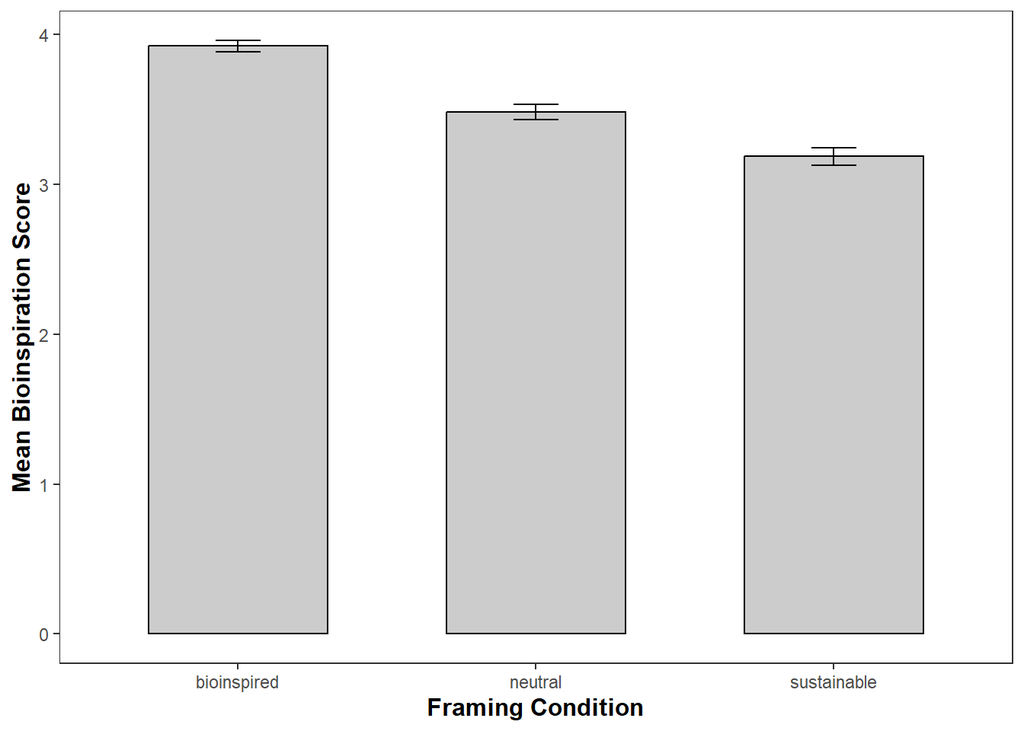

```r
# Summarize means and SE for plotting
bio_plot_data <- data_summary(dat, "mean_Bioinspiration", "framingCondition")
eco_plot_data <- data_summary(dat, "mean_Ecological", "framingCondition")

# --- Bioinspiration Plot ---
ggplot(bio_plot_data, aes(x = framingCondition, y = mean_Bioinspiration)) +
  geom_col(fill = "grey80", color = "black", width = 0.6) +
  geom_errorbar(aes(ymin = mean_Bioinspiration - se, ymax = mean_Bioinspiration + se), width = 0.15) +
  labs(x = "Framing Condition", y = "Mean Bioinspiration Score") +
  theme_apa() +
  theme(
    axis.title = element_text(face = "bold"),
    legend.position = "none"
  )
```

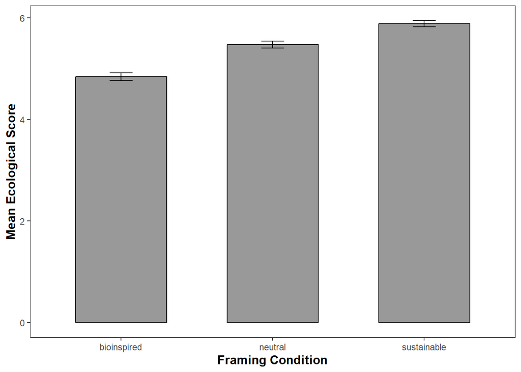

```r
# --- Ecological Dimension Plot ---
ggplot(eco_plot_data, aes(x = framingCondition, y = mean_Ecological)) +
  geom_col(fill = "grey60", color = "black", width = 0.6) +
  geom_errorbar(aes(ymin = mean_Ecological - se, ymax = mean_Ecological + se), width = 0.15) +
  labs(x = "Framing Condition", y = "Mean Ecological Score") +
  theme_apa() +
  theme(
    axis.title = element_text(face = "bold"),
    legend.position = "none"
  )
```

## 6.3 Spillover

We are comparing the effect size or magnitude of:

- How much “bioinspired” framing boosts sustainability ratings.
- How much “sustainable” framing boosts bioinspiration ratings.

```r
# Subset only relevant cases and variables
dat_subset <- dat %>%
  filter(framingCondition %in% c("bioinspired", "sustainable")) %>%
  select(PROLIFIC_PID, framingCondition, mean_Bioinspiration, mean_Ecological)


# Standardize the two scales
dat_subset <- dat_subset %>%
  mutate(
    z_Bioinspiration = scale(mean_Bioinspiration)[, 1],
    z_Sustainability = scale(mean_Ecological)[, 1]
  )


# Convert to long format
dat_long_scaled <- dat_subset %>%
  pivot_longer(cols = c(z_Bioinspiration, z_Sustainability),
               names_to = "ratingType",
               values_to = "ratingScore") %>%
  mutate(
    ratingType = recode(ratingType,
                        "z_Bioinspiration" = "Bioinspiration",
                        "z_Sustainability" = "Sustainability"),
    framingCondition = factor(framingCondition),
    ratingType = factor(ratingType)
  )
```

The interaction term now reflects difference in effect sizes in standard deviation units (comparable spillover strength):

```r
# Run interaction model
model_scaled <- lm(ratingScore ~ framingCondition * ratingType, data = dat_long_scaled)
summary(model_scaled)
```

```
Call:
lm(formula = ratingScore ~ framingCondition * ratingType, data = dat_long_scaled)

Residuals:
    Min      1Q  Median      3Q     Max
-3.5716 -0.5824  0.1032  0.5826  2.3409

Coefficients:
                                                     Estimate Std. Error
(Intercept)                                           0.48023    0.06345
framingConditionsustainable                          -0.94828    0.08917
ratingTypeSustainability                             -0.96805    0.08974
framingConditionsustainable:ratingTypeSustainability  1.91153    0.12610
                                                     t value Pr(>|t|)
(Intercept)                                            7.568 1.08e-13 ***
framingConditionsustainable                          -10.635  < 2e-16 ***
ratingTypeSustainability                             -10.788  < 2e-16 ***
framingConditionsustainable:ratingTypeSustainability  15.159  < 2e-16 ***
---
Signif. codes:  0 '***' 0.001 '**' 0.01 '*' 0.05 '.' 0.1 ' ' 1

Residual standard error: 0.8792 on 774 degrees of freedom
Multiple R-squared:  0.2289,    Adjusted R-squared:  0.2259
F-statistic:  76.6 on 3 and 774 DF,  p-value: < 2.2e-16
```

```r
dat_long_scaled %>%
  group_by(framingCondition, ratingType) %>%
  dplyr::summarise(
    N = n(),
    mean_DV = mean(ratingScore, na.rm = TRUE)
  )
```

```
# A tibble: 4 × 4
# Groups:   framingCondition [2]
  framingCondition ratingType         N mean_DV
  <fct>            <chr>          <int>   <dbl>
1 bioinspired      Bioinspiration   192   0.480
2 bioinspired      Sustainability   192  -0.488
3 sustainable      Bioinspiration   197  -0.468
4 sustainable      Sustainability   197   0.475
```

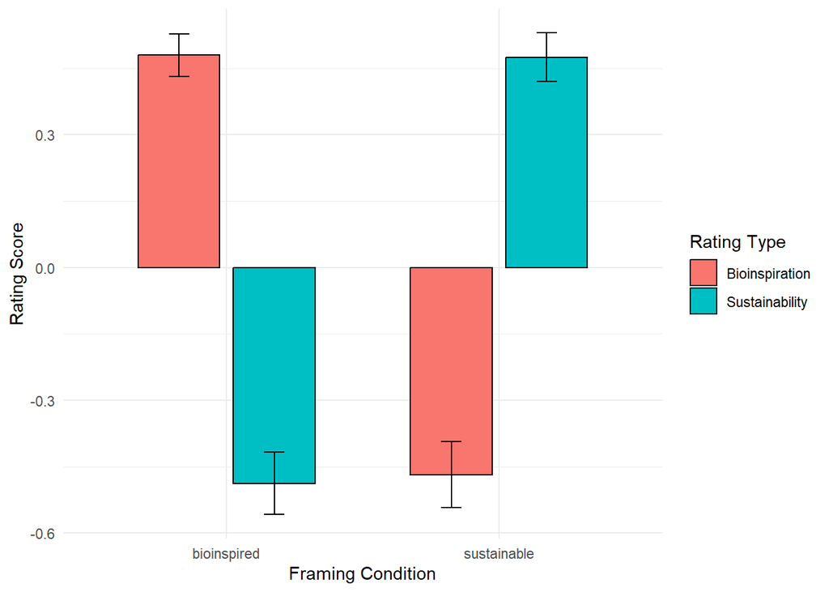

```r
ggplot(dat_long_scaled, aes(x = framingCondition, y = ratingScore, fill = ratingType)) +
  stat_summary(fun = mean, geom = "bar", position = position_dodge(0.7), width = 0.6, color = "black") +
  stat_summary(fun.data = mean_se, geom = "errorbar",
               position = position_dodge(0.7), width = 0.15) +
  labs(x = "Framing Condition", y = "Rating Score", fill = "Rating Type") +
  theme_minimal()
```

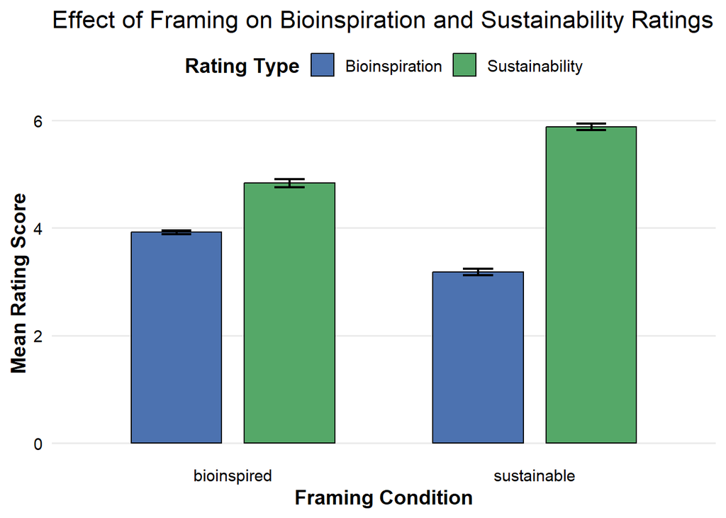

```r
# Reshape from wide to long format
dat_long <- dat_subset %>%
  pivot_longer(cols = c(mean_Bioinspiration, mean_Ecological),
               names_to = "ratingType",
               values_to = "ratingScore") %>%
  mutate(
    ratingType = recode(ratingType,
                        "mean_Bioinspiration" = "Bioinspiration",
                        "mean_Ecological" = "Sustainability"),
    framingCondition = as.factor(framingCondition),
    ratingType = as.factor(ratingType)
  )


ggplot(dat_long, aes(x = framingCondition, y = ratingScore, fill = ratingType)) +
  stat_summary(
    fun = mean, geom = "col", position = position_dodge(0.75),
    width = 0.6, color = "black"
  ) +
  stat_summary(
    fun.data = mean_se, geom = "errorbar",
    position = position_dodge(0.75), width = 0.2, size = 0.8
  ) +
  scale_fill_manual(
    values = c("Bioinspiration" = "#4C72B0", "Sustainability" = "#55A868")
  ) +
  labs(
    x = "Framing Condition",
    y = "Mean Rating Score",
    fill = "Rating Type",
    title = "Effect of Framing on Bioinspiration and Sustainability Ratings"
  ) +
  theme_minimal(base_size = 14) +
  theme(
    axis.title = element_text(face = "bold"),
    axis.text = element_text(color = "black"),
    legend.position = "top",
    legend.title = element_text(face = "bold"),
    panel.grid.major.x = element_blank(),
    panel.grid.minor = element_blank()
  )
```